# Tracking COVID-19

The data is taken from [Our World in Data](https://ourworldindata.org/coronavirus). There are csv files available for download for deaths, total cases, and new cases, each by date.

```r
# https://ourworldindata.org/coronavirus
owid_deaths <- read_csv("total-deaths-covid-19.csv")
owid_totalcases <- read_csv("total-cases-covid-19.csv")
owid_newcases <- read_csv("daily-cases-covid-19.csv ")

#column names that the data sets should be joined as
match_cols <- c("Entity", "Code", "Date")

#do nested inner_joins to join all three data sets on the above critera
covid19 <- inner_join(
    owid_deaths
  , inner_join(
        owid_totalcases
      , owid_newcases
      , by =match_cols
      )
  , by=match_cols
  )
```

I’m just look at the data for the United States.

```r
covid19_colnames <- colnames(covid19)
covid19_US <- covid19 %>%
    mutate(Date =
           #change column type to date
           as.Date(
             #parse through current string format mmm d, yyyy
             #requires lubricate package
             parse_date_time(Date, orders=c("mdy"))
             )
         ) %>%
  #only look at USA
  filter(Entity == "United States") %>%
  #only return date and daily count
  #rename long column names into shorter names
  select(
      Date
    , "Total Deaths" = covid19_colnames[4]
    , "Total Cases"  = covid19_colnames[5]
    , "Daily Cases"  = covid19_colnames[6]
    )
```

One important calculation is the growth rate. The growth rate is calculated as follows:

$$\text{Growth Rate} = \frac{ \text{New-Cases}_N}{\text{New-Cases}_{N-1}}$$
where $N$ is a given day.

If the growth rate is below 1 that means the number of new cases is slowing down - this is a positive sign.

I also wanted to look at the dealth percentage which I calculated as the total number of dealths divided by the total number of cases for a given day.

```r
R <- nrow(covid19_US)

covid19_US$`Growth Factor` <- NA

#calculate growth rate
#start with 2 because when r=1; 1-1= 0 (don't have a 0th row)
for (r in 2:R){
  covid19_US$`Growth Factor`[r] <-
    #Growth Factor = New Cases Today / New Cases Yesterday
    covid19_US$`Daily Cases`[r] /  covid19_US$`Daily Cases`[r-1]
}


covid19_US$`Death Percentage` <- NA

# calculate dealth percentage
for (r in 1:R){
  covid19_US$`Death Percentage`[r] <-
    #dealth percentage = total deaths / total cases
    covid19_US$`Total Deaths`[r] /  covid19_US$`Total Cases`[r]
}
```

```r
startdate <- "2020-03-17"
#3/18 - start 'lockdown' ; after large growth factors↕


covid19_US_adj <- covid19_US  %>%
  #only look at data after a given start date
  filter(Date > as.Date(startdate)) %>%
  #remove any NA's that are still present
  drop_na()
```

# Charts

```r
#find current values to use as labels

current_date <- max(covid19_US_adj$Date)

current_values <- covid19_US_adj %>%
    #return row that has current date
    filter(Date == current_date)


current_US_deaths     <- current_values$`Total Deaths`
current_US_totalcases <- current_values$`Total Cases`
current_US_newcases   <- current_values$`Daily Cases`
current_US_growthfact <- current_values$`Growth Factor`
current_US_deathperc  <- current_values$`Death Percentage`
```

## Total Cases

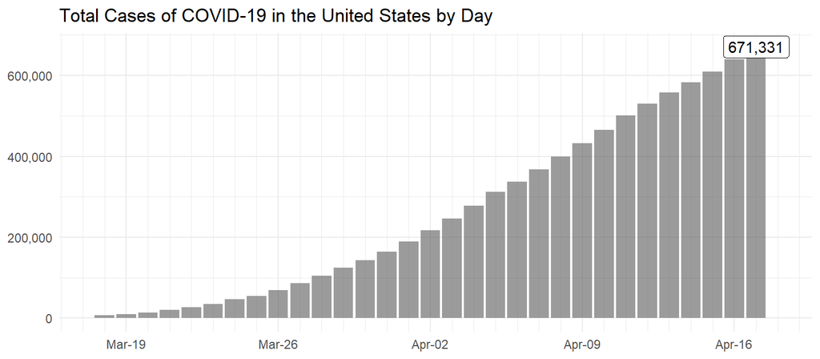

```r
plot_tc <- ggplot(covid19_US_adj, aes(x=Date, y=`Total Cases`))+
  #use geom_col because counts per day have alread been counted
  geom_col(alpha=0.6)+
  ggtitle("Total Cases of COVID-19 in the United States by Day")+
  geom_label(
      data=current_values
    #format label so there is a comma after three places
    , aes(label = formatC(`Total Cases`, big.mark=",", format="d"))
    )+
  theme_minimal()+
  theme(
     legend.position = "none"
    ,axis.title.x=element_blank()
    ,axis.title.y=element_blank()
  )+
  scale_x_date(breaks=date_breaks("7 days")
              , labels = date_format("%b-%d")
              , minor_breaks=date_breaks("1 day")
              , lim = c(as.Date(startdate)+.5, as.Date(current_date)+1)
              )+
  #add commas to numbers in y axis; requires scales package
  scale_y_continuous(labels=comma)
plot_tc
```

## Growth Factor and Daily Cases

Recall that a growth factor less than 1 is a positive sign that the growth of cases is slowing down. Growth factor is directly related to daily cases - if daily cases goes now the growth factor is less than 1; if daily cases goes up the growth factor is greater than one. These two charts represent the same information in two differnt ways.

Start by plotting the growth factor.

```r
plot_gf  <- ggplot(covid19_US_adj, aes(x=Date, y=`Growth Factor`))+
  geom_point()+
  geom_line()+
  geom_hline(yintercept = 1, linetype="dotted", color=AccentCol01)+
  ggtitle("Growth Factor of COVID-19 in the United States by Day")+
  # ADD LABEL
  geom_label(
      data = current_values
    , aes(label = round(`Growth Factor`, 3))
    )+
  theme_minimal()+
  theme(
     legend.position = "none"
    ,axis.title.x=element_blank()
    ,axis.title.y=element_blank()
  )+
  scale_x_date(breaks=date_breaks("7 days")
              , labels = date_format("%b-%d")
              , minor_breaks=date_breaks("1 day")
              , limits = c(as.Date(startdate)+.5, as.Date(current_date)+1)
              )+
  #want growth rate to go to 0
  ylim(0, NA)
```

Then plot the daily cases.

```r
plot_dc <- ggplot(covid19_US_adj, aes(x=Date, y=`Daily Cases`))+
  #use geom_col because counts per day have alread been counted
  geom_col(alpha=0.6)+
  ggtitle("New Cases of COVID-19 in the United States by Day")+
  # ADD LABEL
  geom_label(
      data = current_values
    #format label so there is a comma after three places
    , aes(        label = formatC(`Daily Cases`, big.mark=",", format="d"))
    )+
  theme_minimal()+
  theme(
    #remove all legents
     legend.position = "none"
     # remove x and y axes
    , axis.title.x = element_blank()
    , axis.title.y = element_blank()
  )+
  scale_x_date(breaks=date_breaks("7 days")
              , labels = date_format("%b-%d")
              , minor_breaks=date_breaks("1 day")
              , lim = c(as.Date(startdate)+.5, as.Date(current_date)+1)
              )+
  #add commas to numbers in y axis; requires scales package
  scale_y_continuous(labels=comma)
```

Put the plots together and have the plot axes line up by using grobs within the `grid.draw` function.

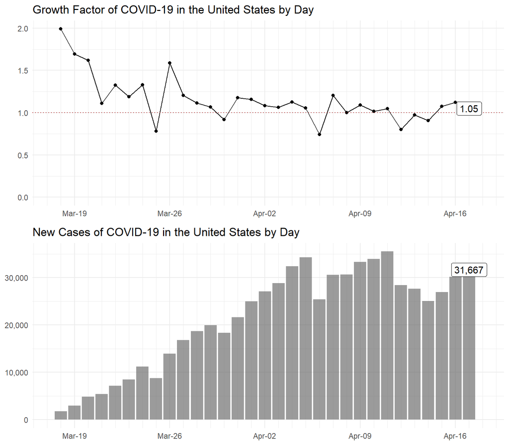

```r
gGF <- ggplotGrob(plot_gf)
gDC <- ggplotGrob(plot_dc)
grid.newpage()
grid.draw(rbind(gGF, gDC))
```

## Total Deaths and Death Percentage

In order to have separate axes on the same plot - I have to start by finding the multiplier that will transform the primary axis into the secondary axis. I start by defining two function: one for finding rounding to a specific base (i.e. rounding to the nearest 5,000) and a function for finding the upper limit for the primary y-axis.

```r
func_mround <- function(x, base){
  base*round(x/base)
}

Ylim <- function(curr_val, base){
round_curr_val <- func_mround(curr_val, base)
if( round_curr_val - curr_val < 0 ){
  lim <- round_curr_val + base
} else {
  lim <- round_curr_val
}
return(lim)
}
```

I am setting the primary (total dealths) y-axis base to 5,000. That is use to find the upper limit for the primary y-axis. After limit is found; that can be used to calculate the transform multiplier. This takes some extra coding because I want the secondary axis to match up with the primary axis.

As an example, say the primary axis is from 0 to 20 and it has 4 breaks (so 5, 10, 15, 20). Say the secondary axis is a percentage. I want to make sure that the the upper limit of the secondary axis is divisible by 4 so that the ‘breaks’ line up. If I don’t do this, the secondary axis breaks will not align with the break lines shown in the primary axis - this makes the plot harder to read.

```r
#td = total deaths
#set base for first axis
td_base <- 5000

#first/main y-axis limit
td_y1lim  <- Ylim(current_US_deaths, td_base)

#max value for the secondary axis
maxdeathperc <- max(covid19_US_adj$`Death Percentage`, na.rm=TRUE)

#set transform for sec axis
#adjust the decimal to be the top value you want on the sec axis
# i.e. if you want the top value make it ylimit*(1/.10)
# the main axis is broken into 7 lines so I wanted a limit ....
#    ... that could also be broken into 7 lines; hence .07

#want both axes to have the same divsors
#this way the secondary axis will match up with the primary axis
divisor <- td_y1lim/td_base
#round to the nearest percentage
dp_base <- divisor/100
Rmaxdeathperc <- func_mround(maxdeathperc, dp_base)

#if the round is < actual then limit is round + sec_base
if( Rmaxdeathperc - maxdeathperc < 0 ){
  td_y2lim <- Rmaxdeathperc + dp_base
} else {
  td_y2lim <- Rmaxdeathperc
}
td_transform <- td_y1lim*(1/td_y2lim)
```

Start by plotting the primary data: total deaths.

```r
plot_td <- ggplot(covid19_US_adj, aes(x=Date))+
  #use geom_col because counts per day have alread been counted
  geom_col(aes(y=`Total Deaths`), alpha=0.6)+
  #add total dealths label
  geom_label(
      data = current_values
    #format label so there is a comma after three places
    , aes(
        label = formatC(`Total Deaths`, big.mark=",", format="d")
      , y     = `Total Deaths`
      )
    )
```

Then, plot the secondary data: death percentage.

```r
#add secondary axis data
plot_td <- plot_td +
  geom_line(
    data = covid19_US_adj,
    #transformatio to match secondary axis below
      aes(y=`Death Percentage`*td_transform)
    , color=AccentCol01
    , size= 1
    )+
  geom_point(
    data = covid19_US_adj,
    #transformatio to match secondary axis below
      aes(y=`Death Percentage`*td_transform)
    #color
    , color=AccentCol01
    , size= 2
    )+
  #add label to most recent value
  geom_label_repel(
      data = current_values
    , aes(
        label = percent(`Death Percentage`, accuracy=0.001)
      # remember to add the transform!
      , y     = `Death Percentage`*td_transform
      )
    , seed = 100
    , box.padding = 0.6
    , hjust = 0
    , vjust = 1
    , color = AccentCol01
    )
```

It is imparative to add the scales.

```r
plot_td <- plot_td +
  #scale the date to be onece a week
  #add specific limits so it will line up with geom_line
  scale_x_date(breaks=date_breaks("7 days")
              , labels = date_format("%b-%d")
              , minor_breaks=date_breaks("1 day")
              , lim = c(as.Date(startdate)+.5, as.Date(current_date)+1)
              )+
  #add commas to numbers in y axis; requires scales package
  scale_y_continuous(
      limits = c(0, td_y1lim)
    #add commas to numbers in y axis; requires scales package
    , labels = comma
    #this transformation MUST match the transformation above
    #divide by current_US_deaths leads to an axis of 0 to 1
    #divide by current_US_deaths*10 leads to an axis of 0 to 0.1
    , sec.axis = sec_axis(~./td_transform)    )
```

Finally, a title and other themes are specified.

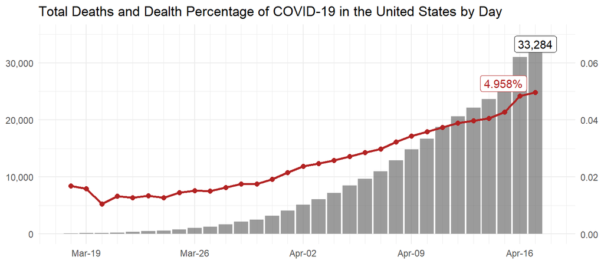

```r
plot_td <- plot_td +
  #add title
  ggtitle("Total Deaths and Dealth Percentage of COVID-19 in the United States by Day")+
  #minimal theme
  theme_minimal()+
  theme(
    #remove all legents
     legend.position = "none"
     # remove x and y axes
    , axis.title.x = element_blank()
    , axis.title.y = element_blank()
  )

plot_td
```

# Values for Past Week

```r
#transpose table; easier to read
covid19_US_adj %>%
  arrange(Date) %>%
  top_n(7, wt=Date) %>%
  #format data for output tabel
  mutate(
      `Total Deaths` = formatC(`Total Deaths`, big.mark=",", format="d")
    , `Total Cases` = formatC(`Total Cases`, big.mark=",", format="d")
    , `Daily Cases`  = formatC(`Daily Cases`, big.mark=",", format="d")
    , `Growth Factor` = round(`Growth Factor`, 4)
    , `Death Percentage` = percent(`Death Percentage`, accuracy=0.001)
  ) %>%
  kable(align=c('l', rep('r', 5))) %>%
  kable_styling(
    bootstrap_options = c(
      #adds stiped color to rows
        "striped"
      #highlight row when hover over it
      , "hover"
      #table doesn't have to be full width
      , full_width = F
      )
    ) %>%
  row_spec(7, bold=T, color="white", background = "rgba(0, 0, 0, .5)")
```

| Date | Total Deaths | Total Cases | Daily Cases | Growth Factor | Death Percentage |
| --- | --- | --- | --- | --- | --- |
| 2020-04-11 | 18,777 | 501,560 | 35,527 | 1.0480 | 3.744% |
| 2020-04-12 | 20,608 | 529,951 | 28,391 | 0.7991 | 3.889% |
| 2020-04-13 | 22,108 | 557,571 | 27,620 | 0.9728 | 3.965% |
| 2020-04-14 | 23,649 | 582,594 | 25,023 | 0.9060 | 4.059% |
| 2020-04-15 | 26,057 | 609,516 | 26,922 | 1.0759 | 4.275% |
| 2020-04-16 | 30,985 | 639,664 | 30,148 | 1.1198 | 4.844% |
| 2020-04-17 | 33,284 | 671,331 | 31,667 | 1.0504 | 4.958% |